### Author: Terry Migwi

### Date: 19th September 2020

### Week 14 IP: Anomaly Detection

# 1.Defining the Question

## Specifying the Data Analytic Question

Detect Anomalies from the dataset on sales provided from Carrefour Supermarkets.

## Defining the Metrics for success

This study will be considered successful if:

- A visualization of the anomalies has been brought out clearly

## Understanding the context

Anomaly detection is about identifying outliers in a time series data using mathematical models, correlating it various influencing factors and delivering insights to business decision makers.

**Why is this study important?**

A retailer must adopt anomaly detection as a way of life because it is effortless, easier, cheaper, better and faster. By so doing the retailers will be at an advantage as they will be able to spot peculiarities or outliers in their sales and attend to them soon enough.

## Recording the experimental design

The following are the steps that will be taken in this study:

- Loading the dataset
- Checking for missing values
- Pre-processing the data
- Decomposing the time series data
- visualizing the anomalies
- Recomposing the data

```r
library(tidyverse)
sales_forecasting <- read_csv("C:\\Users\\USER\\Downloads\\IP's datasets\\Module 3 Core - R Programming\\Supermarket_Sales_Forecasting - Sales.csv")
head(sales_forecasting)
```

```
## # A tibble: 6 x 2
##   Date      Sales
##   <chr>     <dbl>
## 1 1/5/2019  549.
## 2 3/8/2019   80.2
## 3 3/3/2019  341.
## 4 1/27/2019 489.
## 5 2/8/2019  634.
## 6 3/25/2019 628.
```

## 2.Data Pre-processing

```r
colSums(is.na(sales_forecasting))
```

```
##  Date Sales
##     0     0
```

There are no missing values in the dataset

```r
#converting Date variable to data datatype


sales_forecasting$Date <- as.Date(sales_forecasting$Date, format = "%m/%d/%Y")

#converting from date format to POSIXct datatype

sales_forecasting[["Date"]] <- as.POSIXct(sales_forecasting$Date, tz=Sys.timezone())

# confirming our date variable has an appropriate datatype
head(sales_forecasting)
```

```
## # A tibble: 6 x 2
##   Date                Sales
##   <dttm>              <dbl>
## 1 2019-01-05 03:00:00 549.
## 2 2019-03-08 03:00:00  80.2
## 3 2019-03-03 03:00:00 341.
## 4 2019-01-27 03:00:00 489.
## 5 2019-02-08 03:00:00 634.
## 6 2019-03-25 03:00:00 628.
```

```r
#loading libraries
library (tibble)  #convert df to tibble
library (dplyr)
library(anomalize)  #
# Decompose data using time_decompose() function in anomalize package.
# We will use stl method which extracts seasonality.

sales_forecasting_ts = sales_forecasting %>%
                          as.tibble()
```

```
## Converting from tbl_df to tbl_time.
## Auto-index message: index = Date
```

```
## Note: Index not ordered. tibbletime assumes index is in ascending order. Results may not be as desired.
```

```
## frequency = 12 seconds
```

```
## Note: Index not ordered. tibbletime assumes index is in ascending order. Results may not be as desired.
```

```
## trend = 12 seconds
```

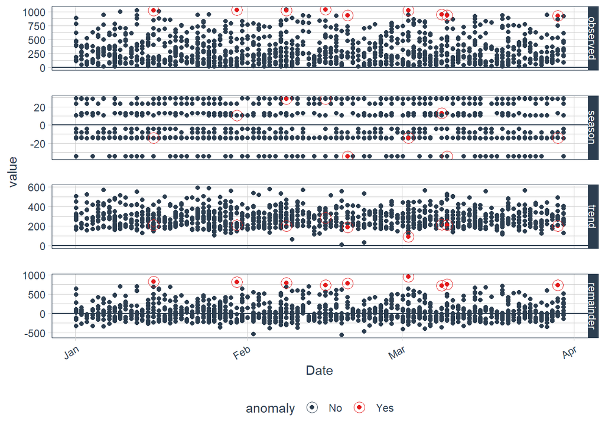

```r
sales_forecasting_ts %>%
  time_decompose(Sales, method = "stl",  frequency = "auto", trend = "auto") %>%
  anomalize(remainder, method = "gesd", alpha = 0.05, max_anoms = 0.1) %>%
  plot_anomaly_decomposition()
```

There are a few anomalies that can be spotted after decomposition of the date

```
## Converting from tbl_df to tbl_time.
## Auto-index message: index = Date
```

```
## Note: Index not ordered. tibbletime assumes index is in ascending order. Results may not be as desired.
```

```
## frequency = 12 seconds
```

```
## Note: Index not ordered. tibbletime assumes index is in ascending order. Results may not be as desired.
```

```
## trend = 12 seconds
```

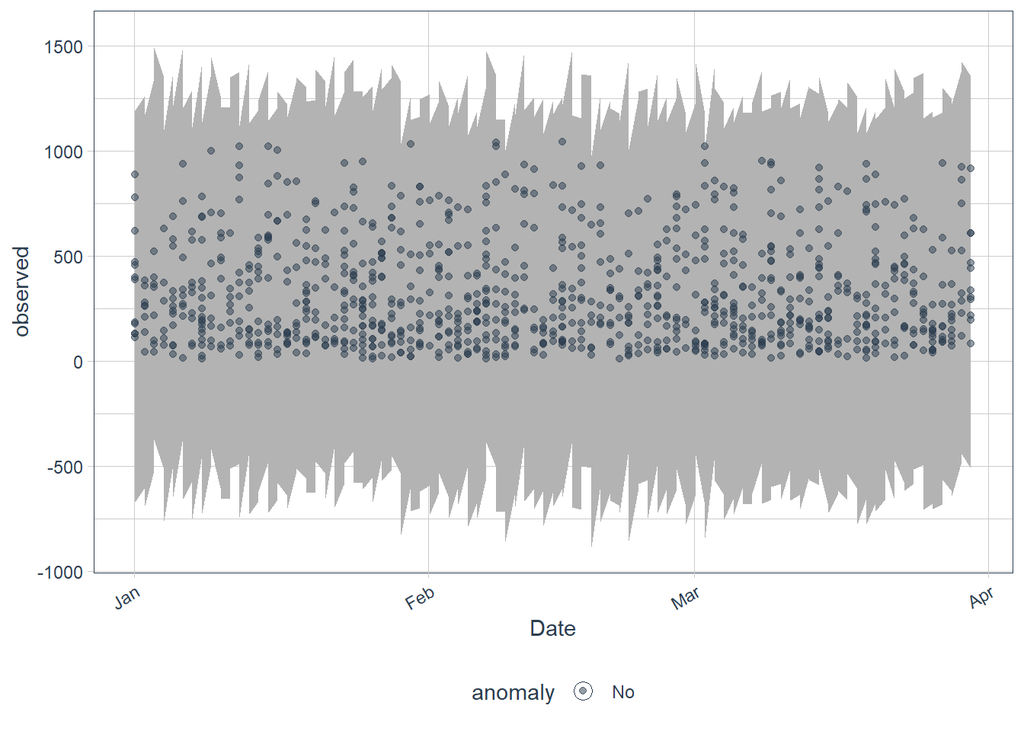

```r
# Plot the data again by recomposing data

sales_forecasting_ts %>%
  time_decompose(Sales) %>%
  anomalize(remainder) %>%
  time_recompose() %>%
  plot_anomalies(time_recomposed = TRUE, ncol = 3, alpha_dots = 0.5)
```

```
## Converting from tbl_df to tbl_time.
## Auto-index message: index = Date
```

```
## Note: Index not ordered. tibbletime assumes index is in ascending order. Results may not be as desired.
```

```
## frequency = 12 seconds
```

```
## Note: Index not ordered. tibbletime assumes index is in ascending order. Results may not be as desired.
```

```
## trend = 12 seconds
```

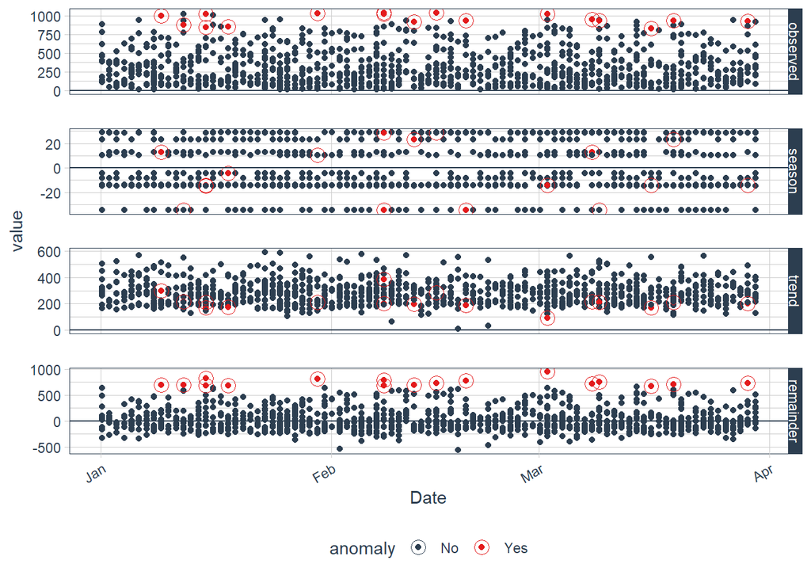

```r
# setting the alpha to 0.002
sales_forecasting_ts %>%
  time_decompose(Sales, method = "stl", frequency = "auto", trend = "auto") %>%
  anomalize(remainder, method = "gesd", alpha = 0.1, max_anoms = 0.02) %>%
  plot_anomaly_decomposition()
```

```
## Converting from tbl_df to tbl_time.
## Auto-index message: index = Date
```

```
## Note: Index not ordered. tibbletime assumes index is in ascending order. Results may not be as desired.
```

```
## frequency = 12 seconds
```

```
## Note: Index not ordered. tibbletime assumes index is in ascending order. Results may not be as desired.
```

```
## trend = 12 seconds
```

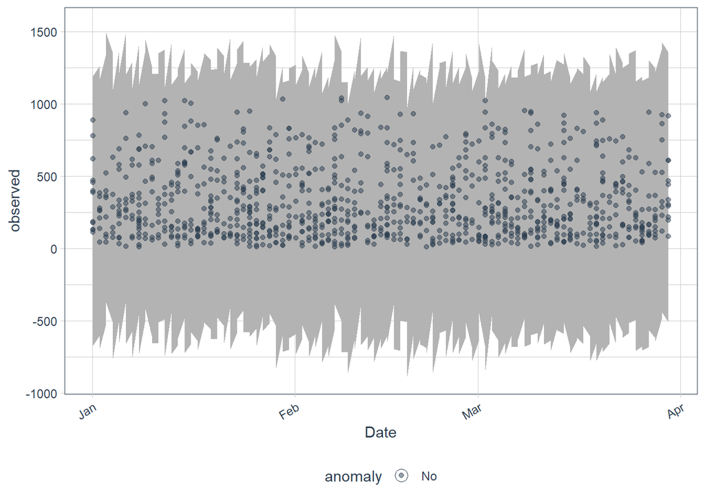

```r
sales_forecasting_ts %>%
  time_decompose(Sales) %>%
  anomalize(remainder) %>%
  time_recompose() %>%
  plot_anomalies(time_recomposed = TRUE, ncol = 3, alpha_dots = 0.5)
```